# UngradedAssn02 - ANSWERS

### Question 1

- Analytical probability calculations use mathematical equations to calculate probabilities.
- Numerical probability calculations use randomly generated numbers (and often iterative simulation) to calculate probabilities.

### Question 2

- One benefit is that they can be used to validate analytical calculations.
- Another benefit is that they can be used even for distributions that are difficult or impossible to define analytically.

### Question 3

- No, it is not a PDF because...
  1. ... the integral of a PDF must be 1.0
  2. ... PDFs cannot have negative values (negative probability is undefined)
  3. ... PDFs must be defined on the domain ($\infty < x < +\infty$)

Note: the first point is mentioned in the Lecture06 notes. The other two points are not mentioned in the Lecture 06 notes, but are also acceptable answers.

### Task 1

```python
np.random.seed(0)
x = np.random.randn( 100000 )  # many values from the standard normal distribution
m = x.mean()
s = x.std( ddof=1 )

print( f'Mean: {m}' )
print( f'SD:   {s}' )
```

```
Mean: 0.0015767005081253399
SD:   0.9973446745632212
```

### Task 2

```python
# For the uniform distribution, we know that P(x>0.1) = 0.9
# This can be verified numerically as follows...

# analytical:
p  = stats.uniform.sf(0.1)

# numerical:
np.random.seed(0)
x  = np.random.rand(10000)
pn = (x>0.1).mean()

print('Analytical:  P(x>0.1) = ', p)
print('Numerical:   P(x>0.1) = ', pn)
```

```
Analytical:  P(x>0.1) =  0.9
Numerical:   P(x>0.1) =  0.8979
```

### Question 4

- The analytical and numerical results were not exactly the same because...
  - Analytical results pertain to an infinitely large set of values, and this is not possible to simulate numerically.
  - Random number generators are imperfect and only approximately characterize the relevant distributions.

### Task 3

| Distribution | P(x>0) | P(x>0.5) | P(x>1.0) | P(x>2.0) | P(x>3.0) |
| --- | --- | --- | --- | --- | --- |
| Uniform | 1.000 | 0.500 | 0.000 | 0.000 | 0.000 |
| Normal | 0.500 | 0.309 | 0.159 | 0.023 | 0.001 |
| $\chi^2$ ($\nu=5$) | 1.000 | 0.992 | 0.963 | 0.849 | 0.700 |

```python
u   = [0, 0.5, 1.0, 2.0, 3.0]
sf0 = stats.uniform.sf(u)
sf1 = stats.norm.sf(u)
sf2 = stats.chi2.sf(u, 5)

print('Uniform: ',     sf0)
print('Normal: ',      sf1)
print('Chi-squared: ', sf2)
```

```
Uniform:  [1.  0.5 0.  0.  0. ]
Normal:  [0.5        0.30853754 0.15865525 0.02275013 0.0013499 ]
Chi-squared:  [1.         0.99212329 0.96256577 0.84914504 0.69998584]
```

### Task 4

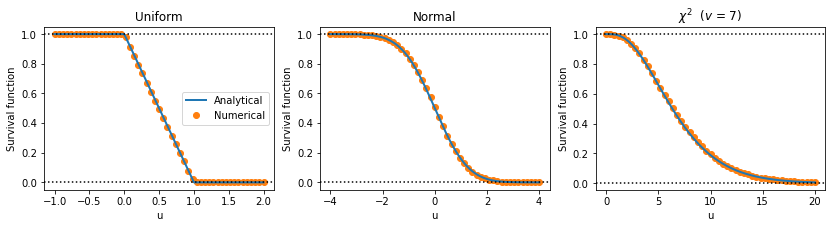

```python
### PART 1:  Analaytical survival functions

# Define ranges of thresholds
u0   = np.linspace(-1, 2, 1001)  # random variable range for the uniform distribution
u1   = np.linspace(-4, 4, 1001)  # random variable range for the normal distribution
u2   = np.linspace(0, 20, 1001)  # random variable range for the chi2 distribution


# Use analytical equations to calculate the probability densities at all x values
sf0  = stats.uniform.sf(u0)     # SF for a uniform random variable
sf1  = stats.norm.sf(u1)        # SF for a normal random variable
sf2  = stats.chi2.sf(u2, 7)     # SF for a chi2 random variable (with degrees of freedom = 7)



### PART 2:  Numerical survival functions

# generate random values:
x0   = np.random.rand(10000)         # uniform
x1   = np.random.randn(10000)        # normal
x2   = np.random.chisquare(7, 10000) # chi-square with 7 degrees of freedom


# specify thresholds for numerical survival function calculations:
u0n  = np.linspace(-1, 2, 51)
u1n  = np.linspace(-4, 4, 51)
u2n  = np.linspace(0, 20, 51)


# calculate survival functions numerically:
sf0n = [(x0>uu).mean()  for uu in u0n]
sf1n = [(x1>uu).mean()  for uu in u1n]
sf2n = [(x2>uu).mean()  for uu in u2n]



### PART 3:  Plot

fig,ax = plt.subplots(1, 3, figsize=(14,3))

ax[0].plot(u0, sf0, linewidth=2, zorder=1, label='Analytical')
ax[1].plot(u1, sf1, linewidth=2, zorder=1)
ax[2].plot(u2, sf2, linewidth=2, zorder=1)

ax[0].plot(u0n, sf0n, 'o', zorder=0, label='Numerical')
ax[1].plot(u1n, sf1n, 'o', zorder=0)
ax[2].plot(u2n, sf2n, 'o', zorder=0)

ax[0].legend()

ax[0].set_title('Uniform')
ax[1].set_title('Normal')
ax[2].set_title('$\chi^2$  ($v$ = 7)')

plt.setp(ax, xlabel='u')
plt.setp(ax, ylabel='Survival function')

[axx.axhline(0, color='k', linestyle=':')  for axx in ax]
[axx.axhline(1, color='k', linestyle=':')  for axx in ax]

plt.show()
```

### Task 5

```
When there is truly no correlation between two variables,
  the probability that the correlation coefficient exceeds 0.5 is:
  P( r > 0.5) =  0.0737
```

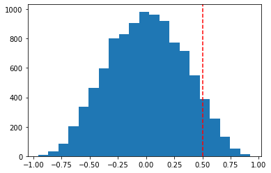

```python
np.random.seed(0)
n      = 10
niter  = 10000
x      = np.arange(n)
r      = []
for i in range(niter):
    y  = np.random.randn(n)
    r.append( np.corrcoef(x, y)[0,1] )
r      = np.array(r)

p      = (r > 0.5).mean()

print('When there is truly no correlation between two variables,')
print('  the probability that the correlation coefficient exceeds 0.5 is:')
print('  P( r > 0.5) = ', p)
print()

plt.figure()
ax = plt.axes()
ax.hist(r, bins=21)
ax.axvline(0.5, color=(1,0,0), linestyle='--')
plt.show()
```